# Week 2 Capstone Milestone Project

Varamihir

December 28, 2017

## Introduction

This report presents some basic exploratory analysis made for the Milestone Report Submission in the Data Science Capstone course by Johns Hopkins at Coursera. The course objective is to apply data science in the area of natural language processing. The final result of the course will be to construct a Shiny application that accepts some text inputed by the user and try to predict what the next word will be. As start the course have provided a set of files containing texts extracted from blogs, news/media sites and twitter, to be used as a input in the creation of a prediction algorithm.

## Getting Data into R

The data(zip file) provided in this course consist of four sets of files in different languages(de_DE - Danish, en_US - English,fi_FI - Finnish an ru_RU - Russian). Each consists 3 text files with texts from blogs, news/media and twitter. In this we will just focus on english language sets of files.

```r
# Load the packages to explore the data.
library(tm)
library(irlba)
library(R.utils)
library(stringi)
library(NLP)
library(RWeka)
library(ggplot2)
library(SnowballC)
library(slam)
library(qdap)
library(ggplot2)
```

```r
# Read the data into R
blog <- readLines("en_US.blogs.txt")
news <- readLines("en_US.news.txt")
twitter <- readLines("en_US.twitter.txt")
```

##### We examined the data sets and summarize our findings(file size,line counts,no.of characters and word counts per line)

```r
#Size of Files
blog.size <- file.info("en_US.blogs.txt")$size/1024^2
news.size <- file.info("en_US.news.txt")$size/1024^2
twitter.size <- file.info("en_US.twitter.txt")$size/1024^2
# No.of Lines
blogtext_length <- length(blog)
newstext_length <- length(readLines("en_US.news.txt"))
twittertext_length <- length(twitter)
#No.of characters
blog_char <- sum(nchar(blog))
news_char <- sum(nchar(news))
twitter_char <- sum(nchar(twitter))
# No.of words
blog_words <- sum(stringi::stri_count_words(blog))
news_words <- sum(stringi::stri_count_words(news))
twitter_words <- sum(stringi::stri_count_words(twitter))
data.frame(source = c("blog","news","twitter"),
           filesize = c(blog.size, news.size,twitter.size),
           No.oflines = c(blogtext_length, newstext_length,twittertext_length),
           No.ofcharacters = c(blog_char, news_char,twitter_char),
           No.ofwords = c(blog_words, news_words,twitter_words))
```

```
##    source filesize No.oflines No.ofcharacters No.ofwords
## 1    blog 200.4242     899288       208361438   38154238
## 2    news 196.2775      77259        15683765    2693898
## 3 twitter 159.3641    2360148       162384825   30218125
```

##### Analyse the first 5 lines in all three data, and find out how do all 3 data look like.

```r
head(blog,5)
```

```
## [1] "In the years thereafter, most of the Oil fields and platforms were named after pagan â€œgodsâ€."
## [2] "We love you Mr. Brown."
## [3] "Chad has been awesome with the kids and holding down the fort while I work later than usual! The kids have been busy together playing Skylander on the XBox together, after Kyan cashed in his $$$ from his piggy bank. He wanted that game so bad and used his gift card from his birthday he has b…
## [4] "so anyways, i am going to share some home decor inspiration that i have been storing in my folder on the puter. i have all these amazing images stored away ready to come to life when we get our home."
## [5] "With graduation season right around the corner, Nancy has whipped up a fun set to help you out with not only your graduation cards and gifts, but any occasion that brings on a change in one's life. I stamped the images in Memento Tuxedo Black and cut them out with circle Nestabilities. I emb…
```

```r
head(news,5)
```

```
## [1] "He wasn't home alone, apparently."
## [2] "The St. Louis plant had to close. It would die of old age. Workers had been making cars there since the onset of mass automotive production in the 1920s."
## [3] "WSU's plans quickly became a hot topic on local online sites. Though most people applauded plans for the new biomedical center, many deplored the potential loss of the building."
## [4] "The Alaimo Group of Mount Holly was up for a contract last fall to evaluate and suggest improvements to Trenton Water Works. But campaign finance records released this week show the two employees donated a total of $4,500 to the political action committee (PAC) Partners for Progress in early…
## [5] "And when it's often difficult to predict a law's impact, legislators should think twice before carrying any bill. Is it absolutely necessary? Is it an issue serious enough to merit their attention? Will it definitely not make the situation worse?"
```

```r
head(twitter,5)
```

```
## [1] "How are you? Btw thanks for the RT. You gonna be in DC anytime soon? Love to see you. Been way, way too long."
## [2] "When you meet someone special... you'll know. Your heart will beat more rapidly and you'll smile for no reason."
## [3] "they've decided its more fun if I don't."
## [4] "So Tired D; Played Lazer Tag & Ran A LOT D; Ughh Going To Sleep Like In 5 Minutes ;)"
## [5] "Words from a complete stranger! Made my birthday even better :)"
```

## Cleaned the data and build a merged corpus

What I noticed that data is filled with URLs, special characters, whitespace, punctuation, stopwords, numbers. We should clean the data before we do any exploratory analysis.Used tm pacakge to remove all.

Data from the 3 files merged together. Since each data is so big, for perfomance reason only 1% from the each data are loaded for the purpose of this milestone report.

```r
set.seed(4567)
# What I noticed use library everytime to load the appropriate package, that will reduce getting error while knitting the documnet.
library(tm)
```

```r
# Sample 1 % of the data to simplify computations.
merged_data <- c(sample(blog, length(blog)*.01), sample(news,length(news)*.01), sample(twitter, length(twitter)*.01))
# Create a corpus and cleaned the data
corpus <- VectorSource(merged_data)
corpus <- VCorpus(corpus)
toSpace <- content_transformer(function(x, pattern) gsub(pattern, " ", x))
corpus <- tm_map(corpus, toSpace, "(f|ht)tp(s?)://(.*)[.][a-z]+")
corpus <- tm_map(corpus, toSpace, "@[^\\s]+")
corpus <- tm_map(corpus, tolower)
corpus <- tm_map(corpus, removeWords, stopwords("english"))
corpus <- tm_map(corpus, removePunctuation)
corpus <- tm_map(corpus, removeNumbers)
corpus <- tm_map(corpus, stripWhitespace)
corpus <- tm_map(corpus, PlainTextDocument)
# Save the copus in a file for future reference
writeLines(as.character(corpus), con ="my.coprus.txt")
save(corpus, file = "corpus.Rdata")
```

## Exploratory Analysis

Data is cleaned and ready to perform exploratory analysis. It would be easy to find the most frequently occuring words in the data. Here we list the most common unigram, bigram and trigram.

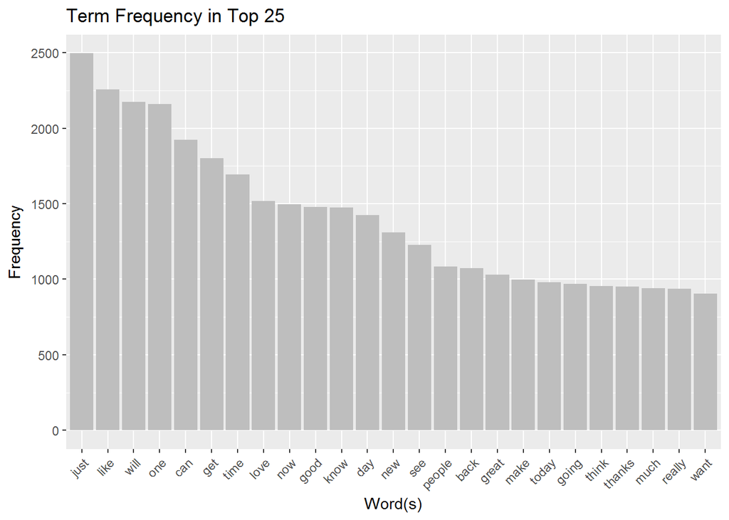

```r
library(tm)
library(RWeka)
library(slam)
library(ggplot2)
plotNGram <- function(n) {
  options(mc.cores=1)
# builds n-gram tokenizer and term document matrix
  tk <- function(x) NGramTokenizer(x, Weka_control(min = n, max = n))
  tdm <- TermDocumentMatrix(corpus, control=list(tokenize=tk))

# find 25 most frequent n-grams in the matrix
  ngram <- as.matrix(rollup(tdm, 2, na.rm=TRUE, FUN=sum))
  ngram <- data.frame(word=rownames(ngram), freq=ngram[,1])
  ngram <- ngram[order(-ngram$freq), ][1:25, ]
  ngram$word <- factor(ngram$word, as.character(ngram$word))

# plots
  ggplot(ngram, aes(x=word, y=freq)) + ggtitle("Term Frequency in Top 25") + geom_bar(stat="Identity", fill="grey") + theme(axis.text.x = element_text(angle = 45, hjust = 1)) + xlab("Word(s)") + ylab("Frequency")
}
plotNGram(1)
```

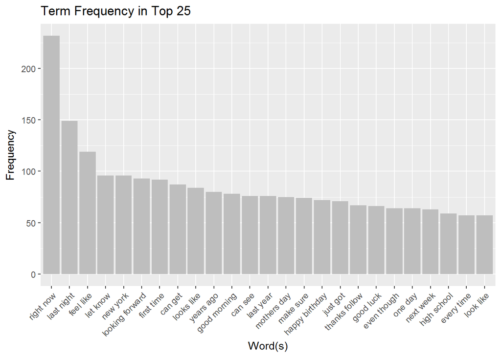

```r
plotNGram(2)
```

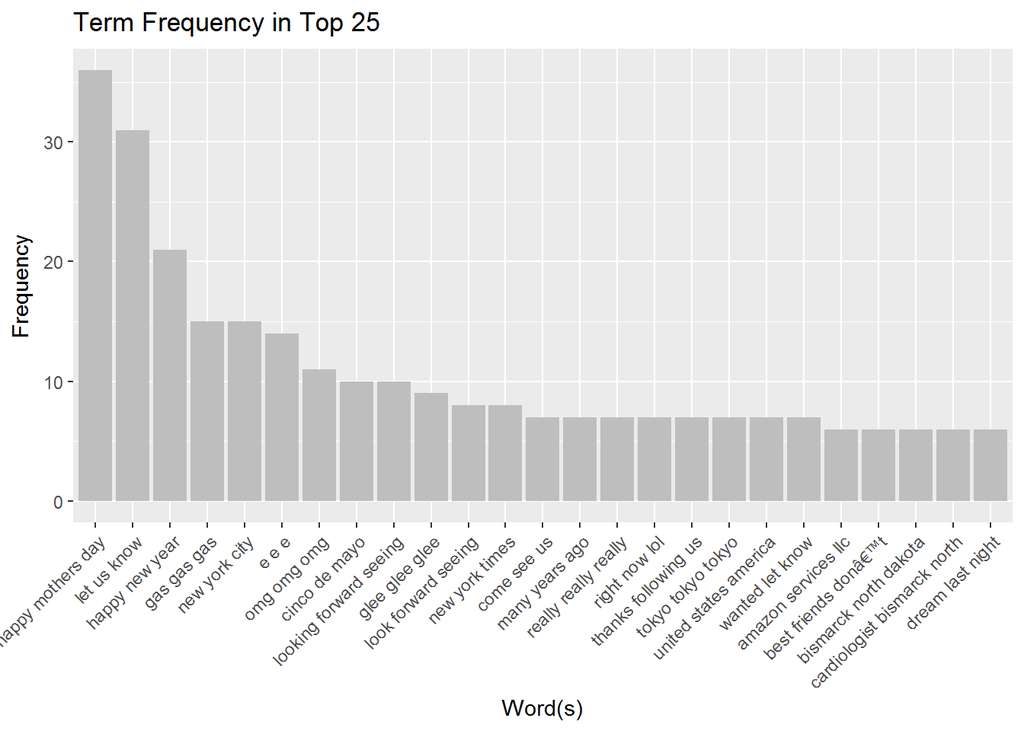

```r
plotNGram(3)
```

##### What I noticed in top 25 words in unigram most frequent word is just, in bigram rightnow and in trigram happy mothersday.

## Feedback for creating a prediction algorithm and Shiny App.

The next step of this capstone project would be to build our predictive algorithm and deploy our algorithm as a Shiny APP.

Our predictive algorithm will be using n-gram model with frequency lookup similar to our exploratory analysis above. One possible strategy would be to use the trigram model to predict the next word. If no matching trigram can be found, then the algorithm would back off to the bigram model, and then to the unigram model if needed.

The user interface of the Shiny app will consist of a text input box that will allow a user to enter a phrase. Then the app will use our algorithm to suggest the most likely next word after a short delay. Our plan is also to allow the user to configure how many words our app should suggest.